# A quick introduction to deep learning, NLP, and LLMs

Marie-Hélène Burle

February 16, 2024

[figure not shown]

# Definitions

### Artificial intelligence (AI)

Any human-made system mimicking animal intelligence. This is a large and very diverse field

### Machine learning (ML)

A subfield of AI that can be defined as computer programs whose performance at a task improves with experience. This includes statistical inference and deep learning

### Deep learning (DL)

A subfield of ML using artificial neural networks with two or more hidden layers

### Natural language processing (NLP)

A subfield of AI focused on human languages. It can use statistical inference or deep learning

# Why has ML become so popular?

## ML allows you to achieve previously impossible tasks

Let’s take the example of image recognition:

In typical computing, a programmer writes code that gives a computer detailed instructions of what to do

Coding all the possible ways—pixel by pixel—that an image can represent, say, a dog is an impossibly large task: there are many breeds of dogs, the image can be a picture, a blurred picture, a drawing, a cartoon, the dog can be in all sorts of positions, wearing clothes, etc.

There just aren’t enough resources to make the traditional programming approach able to create a computer program that can identify a dog in images

By feeding a very large number of dog images to a neural network however, we can train that network to recognize dogs in images that it has never seen (without explicitly programming how it does this!)

## Old concept … new computing power

The concept is anything but new: Arthur Samuel came up with it in 1949 and built a self-learning Checkers-playing program in 1959

Machine learning consists of feeding vast amounts of data to algorithms to strengthen *pathways*, so the excitement for the approach became somewhat dormant due to the lack of computing power and the lack of training data at the time

The advent of powerful computers, GPUs, and massive amounts of data has brought the old concept to the forefront

[figure not shown]

from [xkcd.com](https://xkcd.com/)

# So how does it all work?

It depends on the type of learning

## Supervised learning

- *Regression* is a form of supervised learning with continuous outputs
- *Classification* is supervised learning with discrete outputs

Supervised learning uses training data in the form of example input/output pairs

### Goal

Find the relationship between inputs and outputs

## Unsupervised learning

Clustering, social network analysis, market segmentation, PCA … are all forms of unsupervised learning

Unsupervised learning uses unlabelled data

### Goal

Find structure within the data

## Reinforcement learning

The algorithm explores by performing random actions and these actions are rewarded or punished (bonus points or penalties)

This is how algorithms learn to play games

# Let’s explore the case of supervised learning

## Decide on an architecture

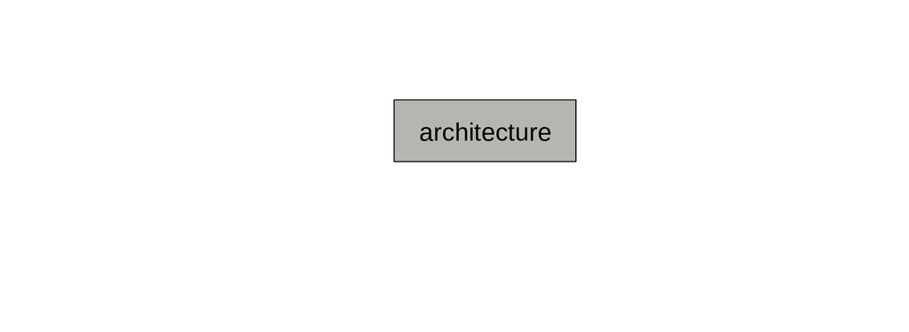

The architecture won’t change during training

The type of architecture you choose (e.g. CNN, Transformer) depends on the type of data you have (e.g. vision, textual). The depth and breadth of your network depend on the amount of data and computing resources you have

## Set some initial parameters

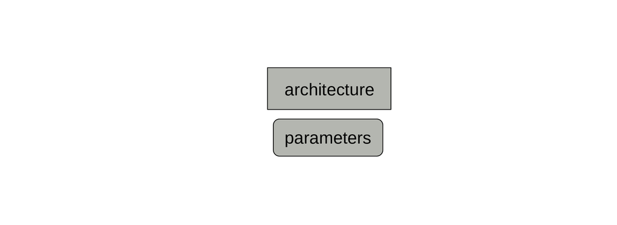

You can initialize them randomly or get much better ones through transfer learning

While the parameters are also part of the model, those will change during training

## Get some labelled data

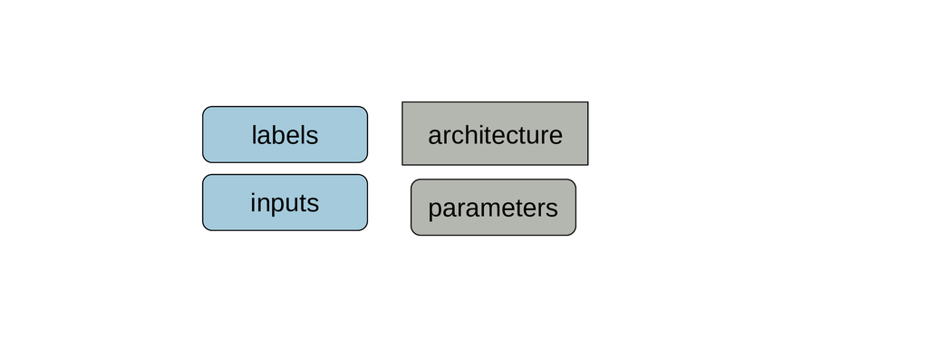

When we say that we need a lot of data for machine learning, we mean “lots of labelled data” as this is what gets used for training models

## Make sure to keep some data for testing

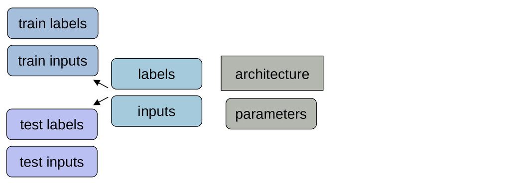

Those data won’t be used for training the model. Often people keep around 20% of their data for testing

## Pass data and parameters through the architecture

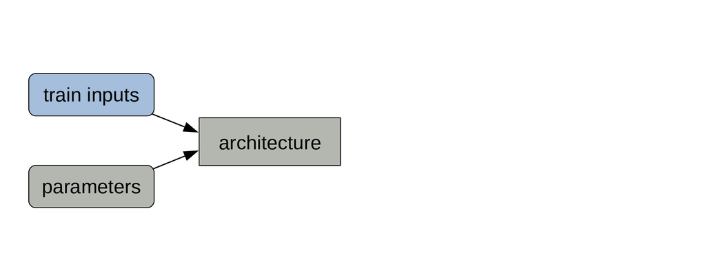

The train data are the inputs and the process of calculating the outputs is the forward pass

## The outputs of the model are predictions

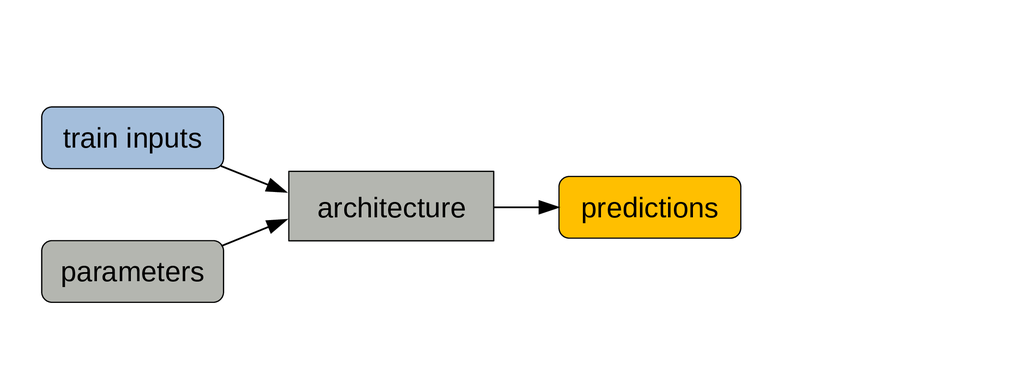

## Compare those predictions to the train labels

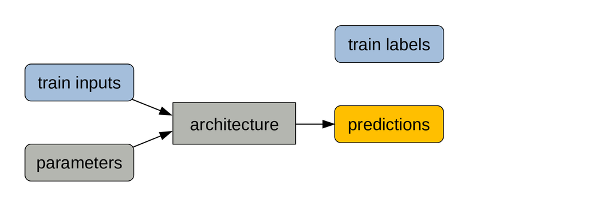

Since our data was labelled, we know what the true outputs are

## Calculate train loss

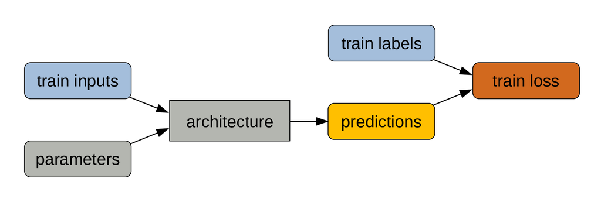

The deviation of our predictions from the true outputs gives us a measure of training loss

## Adjust parameters

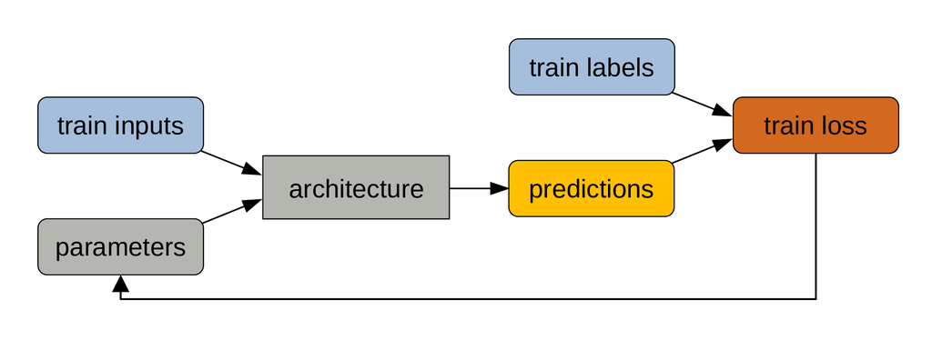

The parameters get automatically adjusted to reduce the training loss through the mechanism of backpropagation. This is the actual training part

This process is repeated many times. Training models is pretty much a giant for loop

## From model to program

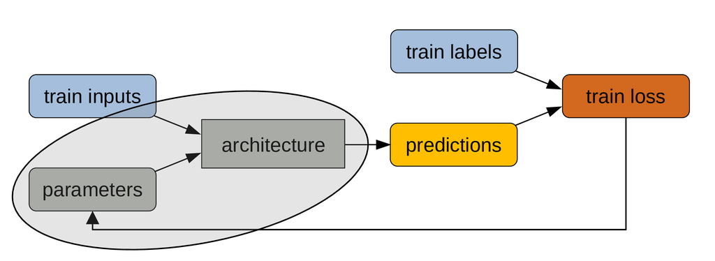

Remember that the model architecture is fixed, but that the parameters change at each iteration of the training process

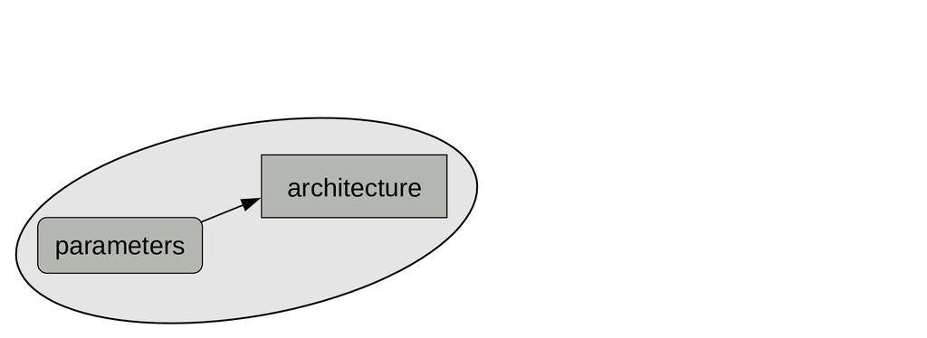

While the labelled data are key to training, what we are really interested in is the combination of architecture + final parameters

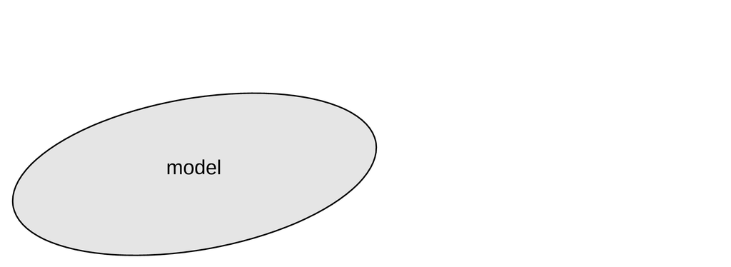

When the training is over, the parameters become fixed. Which means that our model now behaves like a classic program

## Evaluate the model

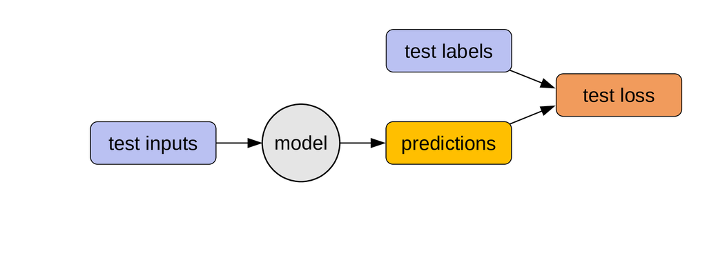

We can now use the testing set (which was never used to train the model) to evaluate our model: if we pass the test inputs through our program, we get some predictions that we can compare to the test labels (which are the true outputs)

This gives us the test loss: a measure of how well our model performs

## Use the model

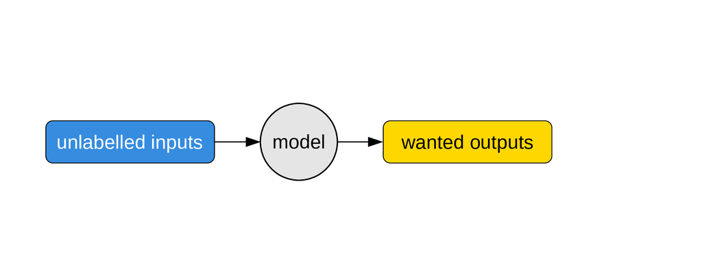

Now that we have a program, we can use it on unlabelled inputs to get what people ultimately want: unknown outputs

This is when we put our model to actual use to solve some problem

# Artificial neural networks

In biological networks, the information consists of action potentials (neuron membrane rapid depolarizations) propagating through the network. In artificial ones, the information consists of tensors (multidimensional arrays) of weights and biases: each unit passes a weighted sum of an input tensor with an additional—possibly weighted—bias through an activation function before passing on the output tensor to the next layer of units

Artificial neural networks are a series of layered units mimicking the concept of biological neurons: inputs are received by every unit of a layer, computed, then transmitted to units of the next layer. In the process of learning, experience strengthens some connections between units and weakens others

*Schematic of a biological neuron:*

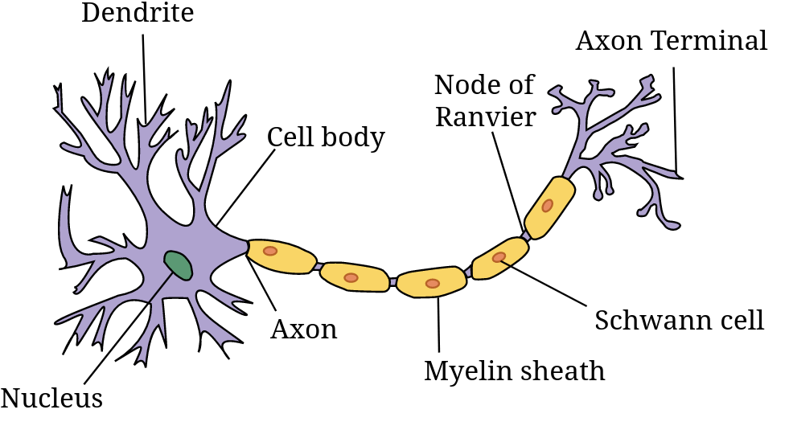

from [Dhp1080, Wikipedia](https://commons.wikimedia.org/w/index.php?curid=1474927)

*Schematic of an artificial neuron:*

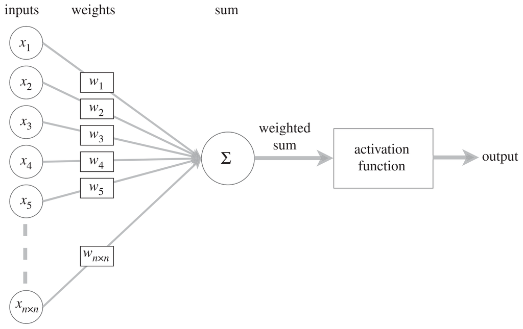

modified from [O.C. Akgun & J. Mei 2019](https://royalsocietypublishing.org/doi/10.1098/rsta.2019.0163)

While biological neurons are connected in extremely intricate patterns, artificial ones follow a layered structure. Another difference in complexity is in the number of units: the human brain has 65–90 billion neurons. ANN have much fewer units

*Neurons in mouse cortex:*

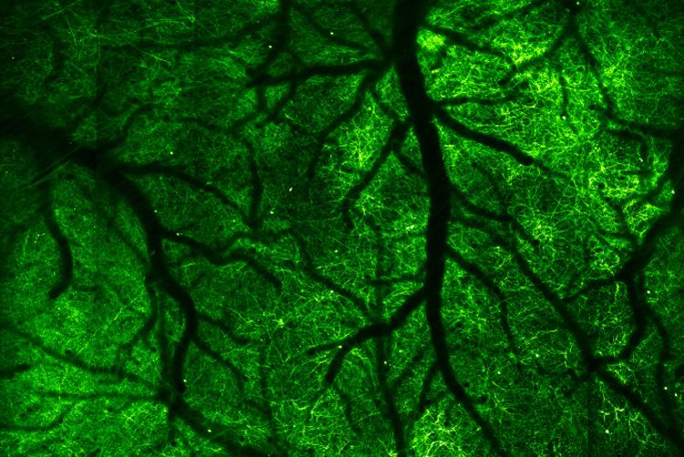

neurons are in green, the dark branches are blood vessels  
image by [Na Ji, UC Berkeley](https://news.berkeley.edu/2020/03/19/high-speed-microscope-captures-fleeting-brain-signals/)

*Neural network with 2 hidden layers:*

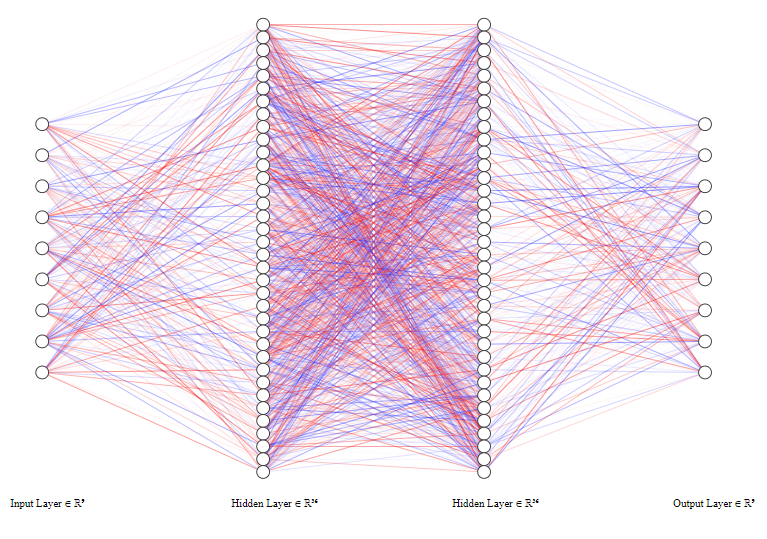

from The Maverick Meerkat

The information in biological neurons is an all-or-nothing electrochemical pulse or action potential. Greater stimuli don’t produce stronger signals but increase firing frequency. In contrast, artificial neurons pass the computation of their inputs through an activation function and the output can take any of the values possible with that function

*Threshold potential in biological neurons:*

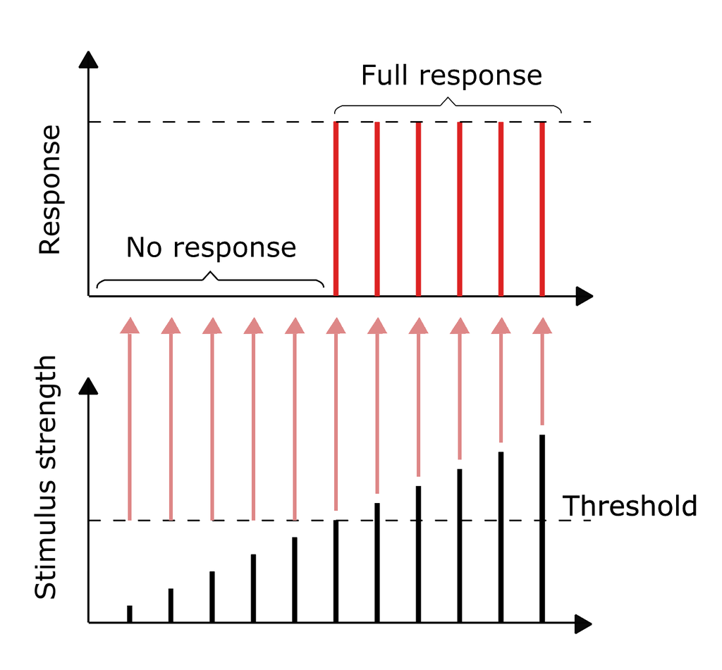

Modified from [Blacktc, Wikimedia](https://commons.wikimedia.org/w/index.php?curid=78013076)

*Some common activation functions in ANNs:*

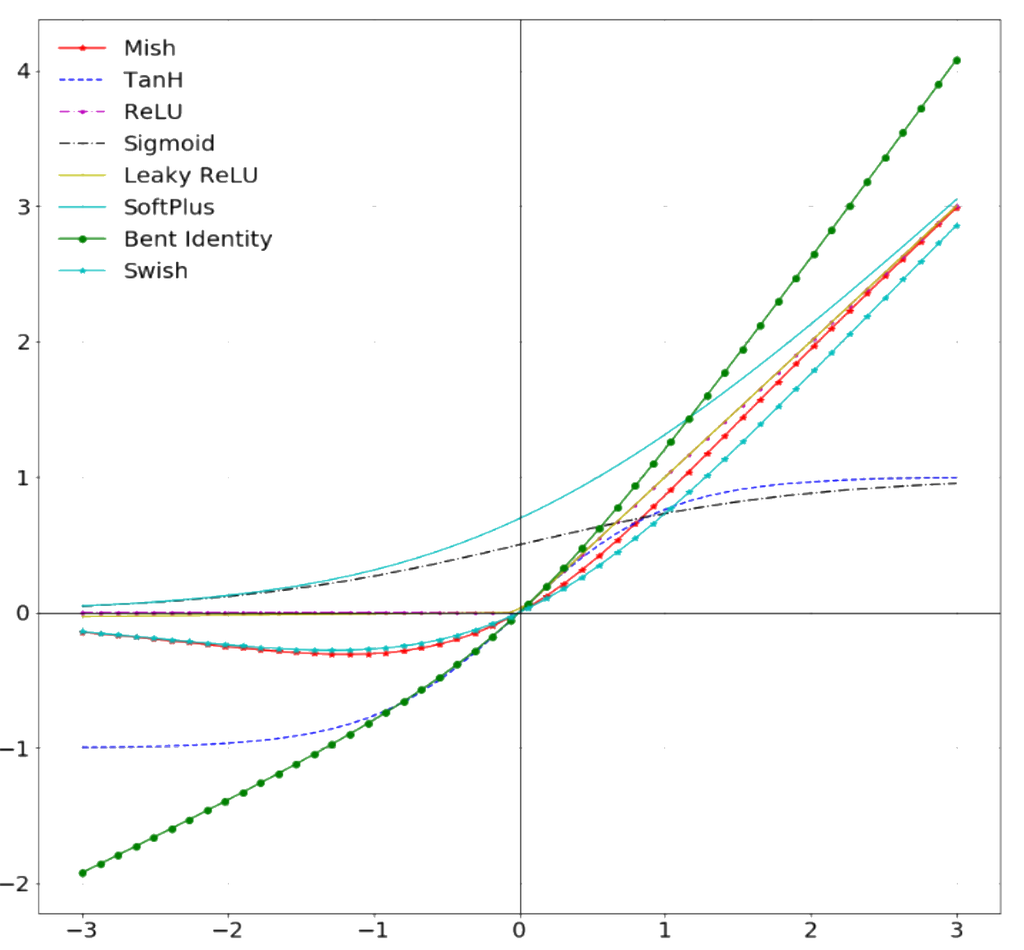

from [Diganta Misra 2019](https://arxiv.org/abs/1908.08681)

## Learning

The process of learning in biological NN happens through neuron death or growth and the creation or loss of synaptic connections between neurons

In ANN, learning happens through optimization algorithms such as gradient descent which minimize cross entropy loss functions by adjusting the weights and biases connecting each layer of neurons over many iterations

# Types of ANN

## Fully connected neural networks

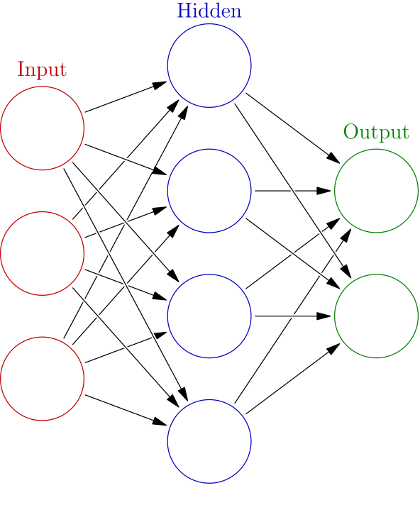

from [Glosser.ca, Wikipedia](https://commons.wikimedia.org/w/index.php?curid=24913461)

Each neuron receives inputs from every neuron of the previous layer and passes its output to every neuron of the next layer

## Convolutional neural networks

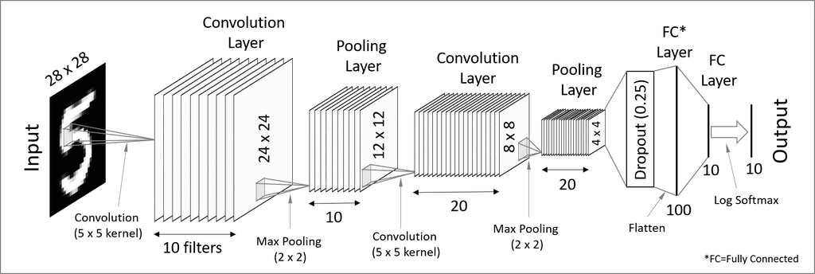

from [Programming Journeys by Rensu Theart](https://codetolight.wordpress.com/2017/11/29/getting-started-with-pytorch-for-deep-learning-part-3-neural-network-basics/)

Convolutional neural networks (CNN) are used for spatially structured data (e.g. images)

Images have huge input sizes and would require a very large number of neurons in a fully connected neural net. In convolutional layers, neurons receive input from a subarea (called *local receptive field*) of the previous layer. This greatly reduces the number of parameters. Optionally, pooling (combining the outputs of neurons in a subarea) reduces the data dimensions

## Recurrent neural networks

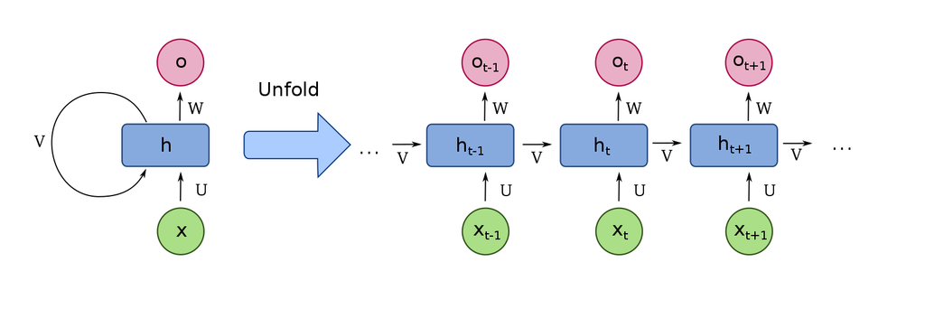

from [fdeloche, Wikipedia](https://commons.wikimedia.org/wiki/File:Recurrent_neural_network_unfold.svg)

Recurrent neural networks (RNN) such as Long Short-Term Memory (LSTM) are used for chain structured data (e.g. text)

They are not feedforward networks (i.e. networks for which the information moves only in the forward direction without any loop)

## Transformers

A combination of two RNNs (the *encoder* and the *decoder*) is used in sequence to sequence models for translation or picture captioning

In 2014 the concept of *attention* (giving added weight to important words) was developed, greatly improving the ability of such models to process a lot of data

The problem with recurrence is that it is not easy to parallelize (and thus to run fast on GPUs)

In 2017, a new model—the [transformer](https://arxiv.org/abs/1706.03762)—was proposed: by using only attention mechanisms and no recurrence, the transformer achieves better results in an easily parallelizable fashion

With the addition of transfer learning, powerful transformers emerged in the field of [NLP](https://en.wikipedia.org/wiki/Natural_language_processing) (e.g. [Bidirectional Encoder Representations from Transformers (BERT)](https://arxiv.org/abs/1810.04805) from Google and [Generative Pre-trained Transformer-3 (GPT-3)](https://arxiv.org/pdf/2005.14165) from [OpenAI](https://openai.com/))

# ML limitations

## Data bias

**Bias is always present in data**

*Document the limitations and scope of your data as best as possible*

Problems to watch for:

- *Out of domain data*: data used for training are not relevant to the model application
- *Domain shift*: model becoming maladapted as conditions evolve
- *Feedback loop*: initial bias exacerbated over time

The last one is particularly problematic whenever the model outputs the next round of data based on interactions of the current round of data with the real world

Solution: ensure there are human circuit breakers and oversight

[figure not shown]

from [xkcd.com](https://xkcd.com/)

## Transformation of subjects

Algorithms are supposed to help us, not transform us (e.g. YouTube recommendation algorithms)

## Bugs

[Example of bug with real life consequences](https://www.theverge.com/2018/3/21/17144260/healthcare-medicaid-algorithm-arkansas-cerebral-palsy)

# Natural language processing

## What is NLP?

Natural language processing is simply the application of machine learning to human (natural) language

## Applications

- Spam detection
- Translation
- Sentiment analysis
- Predictive text
- Text classification
- Speech recognition
- Natural language generation
- Chatbots
- Search results

## Data processing

- Tokenization: split text into sentences (sentence tokenization) and words (word tokenization)
- Remove punctuation and stopwords (e.g. “the”, “a”, “and”, “is”, “are”)
- Turn all words to lower case
- Keep only the lemma of words ([lemmatization](https://en.wikipedia.org/wiki/Lemmatization))
- Identify word collocations (groups of words that often occur together, such as the bigrams “United States” or “open source”)
- Tagging
- Model training

# Tools

## Many options

Here are just a few:

- [scikit-learn](https://scikit-learn.org/stable/): a Python ML library built on top of [SciPy](https://scipy.org/)
- [Natural Language Toolkit (NLTK)](https://www.nltk.org/): a suite of Python libraries geared towards teaching and research
- [spaCy](https://spacy.io/): Python library geared towards production
- [torchtext](https://pytorch.org/text/stable/index.html), part of the [PyTorch](https://pytorch.org/) project (and many options of added layers on top such as [PyTorch-NLP](https://pytorchnlp.readthedocs.io/en/latest/)): Python library
- [GenSim](https://radimrehurek.com/gensim/): Python library
- [Stanford CoreNLP](https://stanfordnlp.github.io/CoreNLP/): Java library
- [Many libraries in the Julia programming language](https://juliapackages.com/c/machine-learning)

## Which one to choose?

Choose an open source tool (i.e. stay away from proprietary software such as MATLAB)

- Researchers who do not have access to the tool cannot reproduce your methods (open tools = open equitable research)
- Once you graduate, you may not have access to the tool anymore
- Your university may stop paying for a license
- You may get locked-in
- Proprietary tools are often black boxes
- Long-term access is not guaranteed (problem to replicate studies)
- The licenses you have access to may be limiting and a source of headaches
- Proprietary tools fall behind popular open-source tools
- Proprietary tools often fail to address specialized edge cases needed in research

# Resources

## Neural nets

[3Blue1Brown by Grant Sanderson](https://www.3blue1brown.com/) has a series of 4 videos on neural networks which is easy to watch, fun, and does an excellent job at introducing the functioning of a simple neural network

- [What are NN? (19 min)](https://www.youtube.com/embed/aircAruvnKk)
- [How do NN learn? (21 min)](https://www.youtube.com/embed/IHZwWFHWa-w)
- [What is backpropagation? (14 min)](https://www.youtube.com/embed/Ilg3gGewQ5U)
- [How does backpropagation work? (10 min)](https://www.youtube.com/embed/tIeHLnjs5U8)

## Open-access preprints

- [ML papers in the computer science category on arXiv](https://arxiv.org/list/cs.LG/recent)
- [ML papers in the stats category on arXiv](https://arxiv.org/list/stat.ML/recent)
- [Distill ML research online journal](https://distill.pub/)

## Advice and sources

- [Advice and sources from ML research student](https://tomsilver.github.io/blog/2024/lessons/)

## Getting help

Stack Overflow:

- [[machine-learning] tag](https://stackoverflow.com/questions/tagged/machine-learning)
- [[deep-learning] tag](https://stackoverflow.com/questions/tagged/deep-learning)
- [[supervised-learning] tag](https://stackoverflow.com/questions/tagged/supervised-learning)
- [[unsupervised-learning] tag](https://stackoverflow.com/questions/tagged/unsupervised-learning)
- [[semisupervised-learning] tag](https://stackoverflow.com/questions/tagged/semisupervised-learning)
- [[reinforcement-learning] tag](https://stackoverflow.com/questions/tagged/reinforcement-learning)
- [[transfer-learning] tag](https://stackoverflow.com/questions/tagged/transfer-learning)
- [[machine-learning-model] tag](https://stackoverflow.com/questions/tagged/machine-learning-model)
- [[learning-rate] tag](https://stackoverflow.com/questions/tagged/learning-rate)

## Open datasets

- AIBench
- [kaggle](https://www.kaggle.com/datasets)
- [Wikipedia](https://en.wikipedia.org/wiki/List_of_datasets_for_machine-learning_research)

## PyTorch

- [Documentation](https://pytorch.org/docs/stable/index.html)
- [Tutorials](https://pytorch.org/tutorials/)
- [Examples](https://github.com/pytorch/examples)

### Getting help

- [PyTorch Discourse forum](https://discuss.pytorch.org/)
- [Stack Overflow [pytorch] tag](https://stackoverflow.com/questions/tagged/pytorch)

### Pre-trained models

- [PyTorch Hub](https://pytorch.org/hub/)

## Python

### IDE

- [Project Jupyter](https://jupyter.org/)
- [List of IDEs with description](https://wiki.python.org/moin/IntegratedDevelopmentEnvironments)
- [Comparison of IDEs](https://en.wikipedia.org/wiki/Comparison_of_integrated_development_environments#Python)
- [Emacs Python IDE](https://github.com/jorgenschaefer/elpy)

### Getting help

- [Stack Overflow [python] tag](https://stackoverflow.com/questions/tagged/python)